# Can simple, accessible measures reliably predict body fat %?

L07G01 - Modelling Body Fat

Lara Burns, Karin Gao, Qiuyu Liu, Bryan Chan and Hanna Boudara

## Why Predict Body Fat %?

- Accurate health metric
- Helps manage risks (cardiovascular disease, diabetes)
- Informs targeted fitness decisions

**Goal**

Use simple body measurements:

- Age
- Height
- Weight
- Circumferences

**However, people usually rely on:**

- **Oversimplified indicators** (BMI)
- **Expensive / inaccessible** tests (DEXA, hydrostatic)

## Data Cleaning and Splitting

The original data had no missing values. For the variable `Weight`, which was in pounds, was converted to kilograms and `Height`, which was in inches, to centimeters. After this data cleaning, we had the following data set to build our models upon:

```
Rows: 250
Columns: 16
$ Density <dbl> 1.0708, 1.0853, 1.0414, 1.0751, 1.0340, 1.0502, 1.0549, 1.0704…
$ Pct.BF  <dbl> 12.3, 6.1, 25.3, 10.4, 28.7, 20.9, 19.2, 12.4, 4.1, 11.7, 7.1,…
$ Age     <int> 23, 22, 22, 26, 24, 24, 26, 25, 25, 23, 26, 27, 32, 30, 35, 35…
$ Weight  <dbl> 69.95465, 78.57143, 69.84127, 83.78685, 83.56009, 95.35147, 82…
$ Height  <dbl> 172.085, 183.515, 168.275, 183.515, 180.975, 189.865, 177.165,…
$ Neck    <dbl> 36.2, 38.5, 34.0, 37.4, 34.4, 39.0, 36.4, 37.8, 38.1, 42.1, 38…
$ Chest   <dbl> 93.1, 93.6, 95.8, 101.8, 97.3, 104.5, 105.1, 99.6, 100.9, 99.6…
$ Abdomen <dbl> 85.2, 83.0, 87.9, 86.4, 100.0, 94.4, 90.7, 88.5, 82.5, 88.6, 8…
$ Waist   <dbl> 33.54331, 32.67717, 34.60630, 34.01575, 39.37008, 37.16535, 35…
$ Hip     <dbl> 94.5, 98.7, 99.2, 101.2, 101.9, 107.8, 100.3, 97.1, 99.9, 104.…
$ Thigh   <dbl> 59.0, 58.7, 59.6, 60.1, 63.2, 66.0, 58.4, 60.0, 62.9, 63.1, 59…
$ Knee    <dbl> 37.3, 37.3, 38.9, 37.3, 42.2, 42.0, 38.3, 39.4, 38.3, 41.7, 39…
$ Ankle   <dbl> 21.9, 23.4, 24.0, 22.8, 24.0, 25.6, 22.9, 23.2, 23.8, 25.0, 25…
$ Bicep   <dbl> 32.0, 30.5, 28.8, 32.4, 32.2, 35.7, 31.9, 30.5, 35.9, 35.6, 32…
$ Forearm <dbl> 27.4, 28.9, 25.2, 29.4, 27.7, 30.6, 27.8, 29.0, 31.1, 30.0, 29…
$ Wrist   <dbl> 17.1, 18.2, 16.6, 18.2, 17.7, 18.8, 17.7, 18.8, 18.2, 19.2, 18…
```

Our models were built on 80% of the data set, designated as the training data, and the models’ performance was built on the remaining 20% of the data, designated as the test data.

## Exploratory Data Analysis

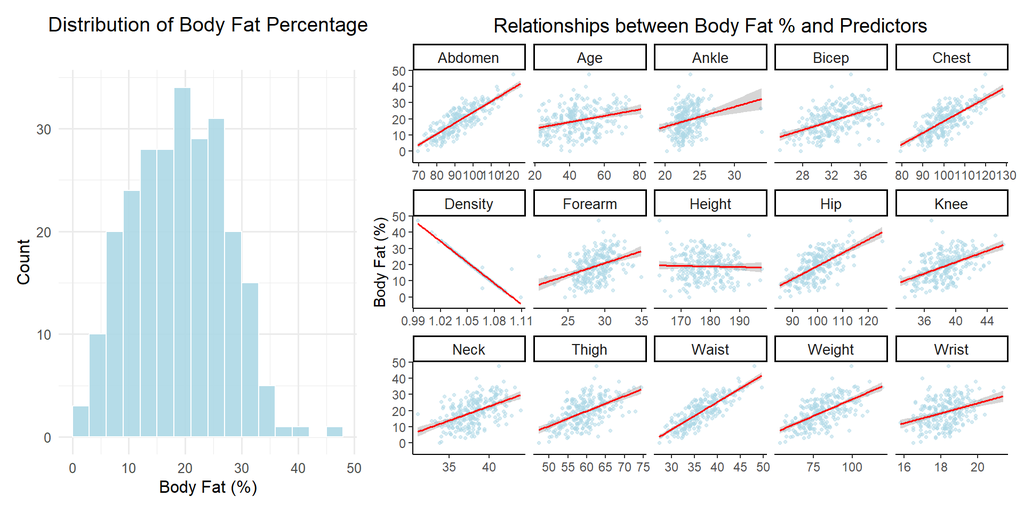

## Full Linear Model

```
            Estimate Std. Error t value Pr(>|t|)
(Intercept)    4.223     28.950   0.146    0.884
Age            0.071      0.036   1.985    0.049
Weight        -0.042      0.186  -0.228    0.820
Height        -0.095      0.090  -1.054    0.293
Neck          -0.628      0.280  -2.242    0.026
Chest         -0.153      0.129  -1.187    0.237
Abdomen        0.963      0.107   9.011    0.000
Hip           -0.244      0.178  -1.369    0.173
Thigh          0.302      0.176   1.715    0.088
Knee          -0.212      0.275  -0.773    0.440
Ankle          0.298      0.231   1.288    0.199
Bicep          0.150      0.191   0.784    0.434
Forearm        0.346      0.221   1.568    0.118
Wrist         -1.368      0.612  -2.235    0.027
```

## Full Linear Model (Continued)

In the full model, majority of predictors are statistically insignificant (with `Pr(>|t|)` > 0.05) and this is potentially due to multi-collinearity between the predictors.

```
Model :
Pct.BF ~ (Density + Age + Weight + Height + Neck + Chest + Abdomen +
    Waist + Hip + Thigh + Knee + Ankle + Bicep + Forearm + Wrist) -
    Density

Complete :
      (Intercept) Age    Weight Height Neck   Chest  Abdomen Hip    Thigh
Waist      0           0      0      0      0      0 50/127       0      0
      Knee   Ankle  Bicep  Forearm Wrist
Waist      0      0      0      0       0
```

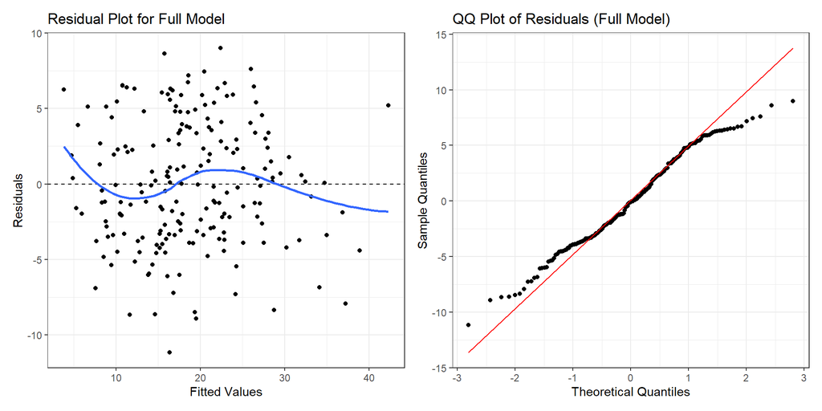

This shows that waist and abdomen are nearly perfectly correlated. This would make model predictions unstable, hence we can try different models selection methods.

## Motivation for Interaction Model

Body fat percentage is influenced by body shape, not just single measurements.  
- Abdomen circumference is one of the strongest predictors of body fat percentage.  
- Chest size can moderate how abdominal size relates to body fat — e.g., two people with the same abdomen size but different chest sizes may have different body compositions.  
- Adding an interaction term (Abdomen × Chest) allows the model to capture this combined effect rather than treating each predictor in isolation.

```
Call:
lm(formula = Pct.BF ~ Abdomen + Waist + Chest + Hip + Abdomen:Chest,
    data = train)

Residuals:
     Min       1Q   Median       3Q      Max
-10.0686  -3.3750  -0.2595   3.3861   9.7345

Coefficients: (1 not defined because of singularities)
                Estimate Std. Error t value Pr(>|t|)
(Intercept)   -31.468325  28.710457  -1.096 0.274405
Abdomen         1.220270   0.306730   3.978 9.78e-05 ***
Waist                 NA         NA      NA       NA
Chest          -0.121474   0.293585  -0.414 0.679505
Hip            -0.348993   0.093663  -3.726 0.000255 ***
Abdomen:Chest  -0.001629   0.002895  -0.563 0.574173
---
Signif. codes:  0 '***' 0.001 '**' 0.01 '*' 0.05 '.' 0.1 ' ' 1

Residual standard error: 4.516 on 195 degrees of freedom
Multiple R-squared:  0.7132,    Adjusted R-squared:  0.7073
F-statistic: 121.2 on 4 and 195 DF,  p-value: < 2.2e-16
```

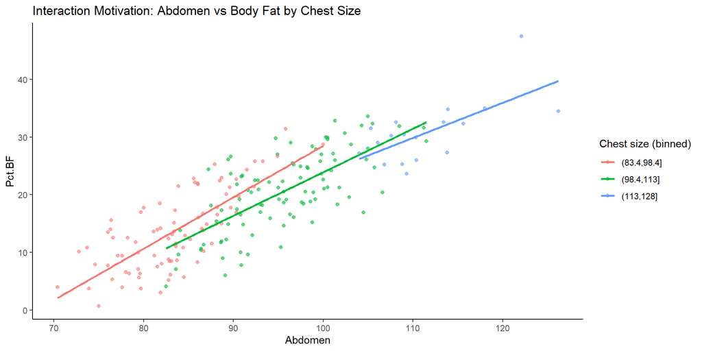

## Assumptions for interaction model

We checked the linear model assumptions using residual diagnostics.  
There are 5 assumptions:

- **Linearity:**  
  The relationship between predictors and the outcome should be linear.
- **Independence of Errors:**  
  Residuals should all be independent of each other.
- **Homoscedasticity:**  
  Residuals should have constant variance across fitted values.
- **Normality of Errors:**  
  Residuals should be approximately normally distributed.
- **No Multicollinearity:**  
  Predictors should not be highly correlated with each other.

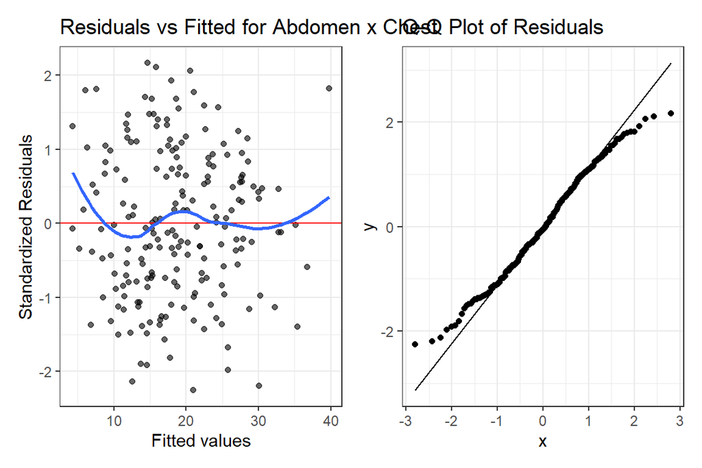

## Multiple Body Sections Model

This model was developed to examine whether a holistic view across different areas of the body can help to produce an accurate prediction of body fat.

```
   Pct.BF   Abdomen     Chest     Waist       Hip     Bicep   Forearm     Wrist
1.0000000 0.8236846 0.7006696 0.8236847 0.6326747 0.4815382 0.3647089 0.3390078
     Neck     Thigh      Knee     Ankle
0.4885242 0.5485496 0.4923077 0.2445556
```

The variables most correlated with body fat percentage from each body section are: `Abdomen` (torso), `Bicep` (arms), `Neck` (neck/head), and `Thigh` (legs). The resulting model using these:

```
            Estimate Std. Error t value Pr(>|t|)
(Intercept)   -18.10       5.64   -3.21     0.00
Abdomen         0.85       0.05   16.31     0.00
Bicep           0.02       0.18    0.10     0.92
Neck           -0.96       0.23   -4.12     0.00
Thigh          -0.10       0.11   -0.88     0.38
```

$\widehat{\text{Pct.BF}} = -18.10 + 0.85 \, \text{Abdomen} + 0.02 \, \text{Bicep} - 0.96 \, \text{Neck} - 0.10 \, \text{Thigh}$

[figure not shown]

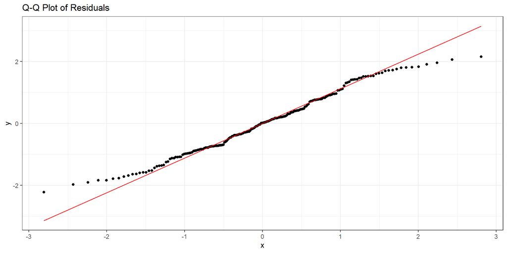

## Backwards Selection

Backward selection simplified the model by removing less significant predictors.

```
            Estimate Std. Error t value Pr(>|t|)
(Intercept)    9.551      9.445   1.011    0.313
Age            0.063      0.034   1.840    0.067
Height        -0.114      0.057  -1.999    0.047
Neck          -0.625      0.264  -2.367    0.019
Chest         -0.147      0.099  -1.491    0.138
Abdomen        0.940      0.099   9.486    0.000
Hip           -0.267      0.155  -1.730    0.085
Thigh          0.285      0.152   1.875    0.062
Forearm        0.370      0.208   1.779    0.077
Wrist         -1.217      0.582  -2.091    0.038
```

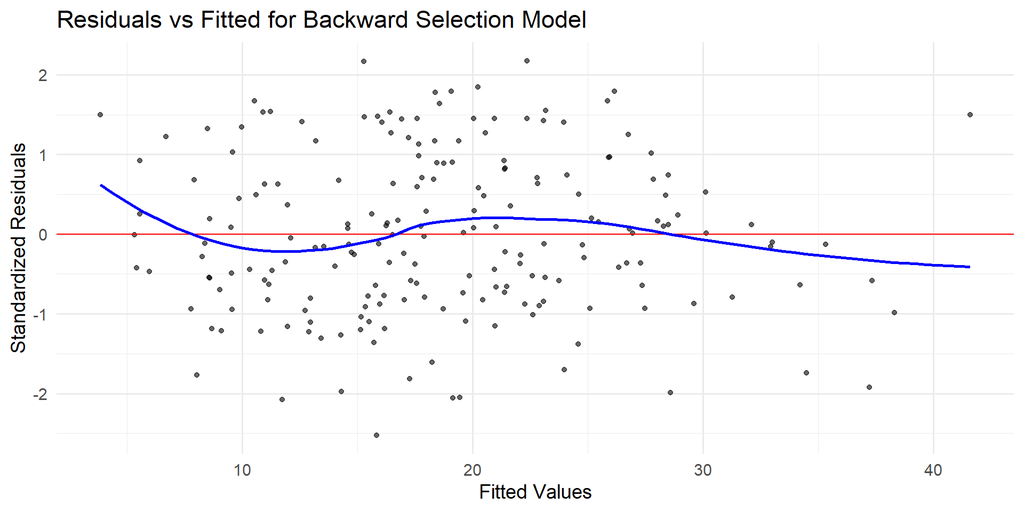

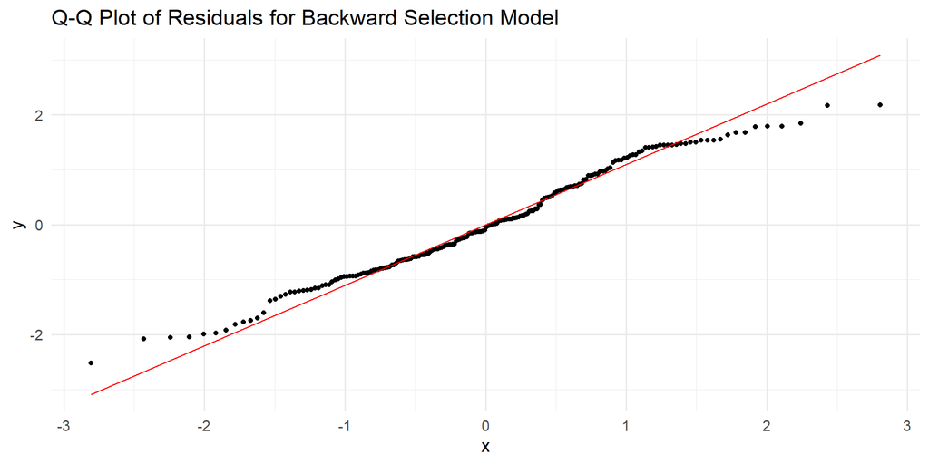

## Forward Selection

```
            Estimate Std. Error t value Pr(>|t|)
(Intercept)  -32.679      8.723  -3.746    0.000
Waist          2.587      0.163  15.838    0.000
Weight        -0.283      0.074  -3.838    0.000
Wrist         -0.983      0.543  -1.809    0.072
Bicep          0.251      0.186   1.350    0.179
Neck          -0.509      0.265  -1.916    0.057
Forearm        0.333      0.220   1.510    0.133
```

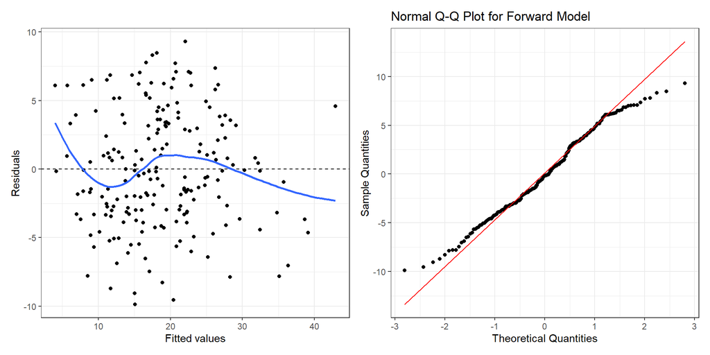

## Comparing Stepwise Models

|  | Forward model |  | Backward model |  |
| --- | --- | --- | --- | --- |
| Predictors | Estimates | p | Estimates | p |
| (Intercept) | -32.68 | **<0.001** | 9.55 | 0.313 |
| Waist | 2.59 | **<0.001** |  |  |
| Weight | -0.28 | **<0.001** |  |  |
| Wrist | -0.98 | 0.072 | -1.22 | **0.038** |
| Bicep | 0.25 | 0.179 |  |  |
| Neck | -0.51 | 0.057 | -0.63 | **0.019** |
| Forearm | 0.33 | 0.133 | 0.37 | 0.077 |
| Age |  |  | 0.06 | 0.067 |
| Height |  |  | -0.11 | **0.047** |
| Chest |  |  | -0.15 | 0.138 |
| Abdomen |  |  | 0.94 | **<0.001** |
| Hip |  |  | -0.27 | 0.085 |
| Thigh |  |  | 0.29 | 0.062 |
| Observations | 200 |  | 200 |  |
| R<sup>2</sup> / R<sup>2</sup> adjusted | 0.740 / 0.732 |  | 0.751 / 0.739 |  |
| AIC | 1161.755 |  | 1159.375 |  |

## Exhaustive Subset Search (BIC)

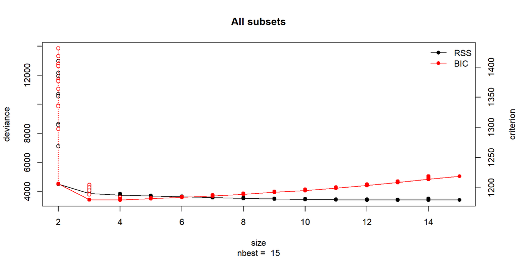

**Takeaway**

**BIC minimum at 3 predictors** → compact model.

Selected: Weight, Waist, Wrist.

## Selected Exhaustive Model (BIC)

| Predictor | Estimate | p |
| --- | --- | --- |
| Weight | -0.23 | 0.000 |
| Waist | 2.47 | 0.000 |
| Wrist | -1.20 | 0.017 |

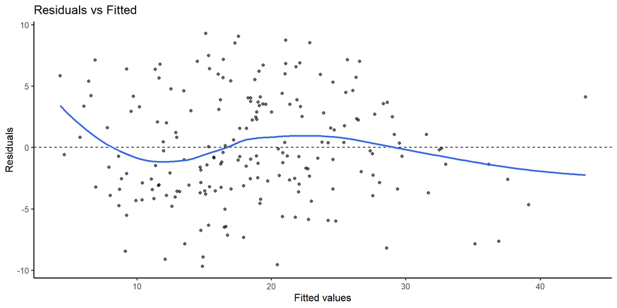

**Summary**

**Resultant Model (BIC)**: $\widehat{\text{Pct.BF}} = -30.32 - 0.23\cdot\text{Weight} +2.47\cdot\text{Waist}-1.2\cdot\text{Wrist}$

- *Residuals*: Slight S-shape but no severe pattern; spread roughly constant.
- *Train adj* $R^2$: 0.73.
- *Test RMSE*: 4.09.

## Comparing All Models

To find the best overall model, all developed models were tested against the remaining 20% of the data set aside. This allowed us to test the models against unseen data.

Model Performance Comparison

[output not shown]

## Best Overall Model

Revisiting the Exhaustive model:

```
            Estimate Std. Error t value Pr(>|t|)
(Intercept)   -30.32       7.60   -3.99     0.00
Weight         -0.23       0.06   -3.84     0.00
Waist           2.47       0.16   15.52     0.00
Wrist          -1.20       0.50   -2.40     0.02
```

$$\widehat{\text{Pct.BF}} = -30.32 - 0.23\cdot\text{Weight}\\ +2.47\cdot\text{Waist}-1.2\cdot\text{Wrist}$$

- **Waist Coefficient: 2.47**

  As weight increases by 1 kg, body fat percentage slightly decreases by -0.23%. This is counter-intuitive, but this could reflect collinearity with other predictors like waist. It is also highly significant, with a p-value of 0.00
- **Wrist Coefficient: -1.2**

  A 1cm increase in wrist circumference is associated with a decrease in body fat percentage by -1.2%. The reasoning for this may be similar to the negative scale of the weight coefficient. The p-value of this coefficient is 0.02, which is less than the critical value 0.05 which indicates a strong and useful predictor.

## Assumptions of the Model

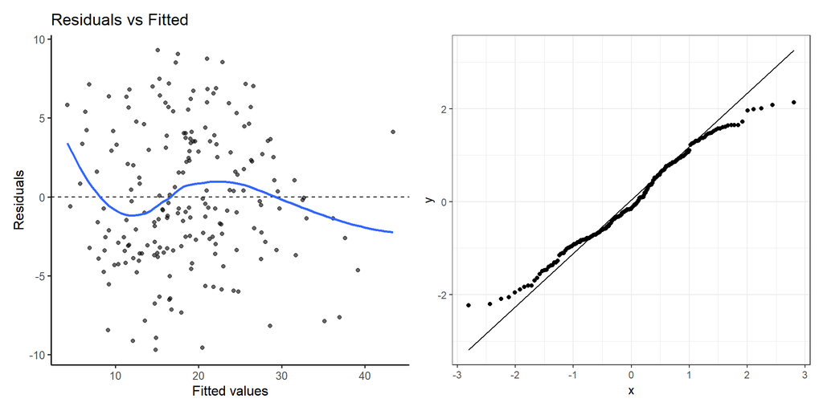

## Key Findings

- The **Exhaustive (BIC) Model** indicates that **waist circumference(2.47)**, **body weight(-0.23)**and **wrist circumference(-1.20)** are the strongest predictors of overall body fat.
- Individuals with **apple-shaped (central-fat) body types** tend to have higher body fat percentages than those with less central fat distribution. Individuals with higher muscle mass or thinner wrists tend to have slightly lower body fat percentages.
- Overall, the findings confirm that body characteristics—especially **waist circumference, body weight and wrist circumference**—are the dominant factors explaining variations in body fat percentage, more than height or age.

## Limitations of the Final Model

- **Sample picked:** BIC choice of model may change on new data.
- **External validity:** Male adults only $\rightarrow$ limited generalisation.
- **Collinearity:** Weight & Waist (highly correlated) $\rightarrow$ unstable coefficients; VIFs $<6$
- **Assumptions:** Mild *non-linearity* (S-shape) and *tail-departures* in QQ plot.

**Future Research**

- Broaden sample (include females, all ages, etc)
- Validate with $k$-fold CV and use regularisation techniques.
- Increase model flexibility to improve **stability** and **fit**
  - Splines
  - Transformations
  - Interactions